# Big Data Analytics - Final Group Report

Authors: Herman Korsgaard Maciej Gorgol Dave Stevens Pawel Godula

For this project we have obtained transactional data from a newly opened luxury hotel in Poland, called Masuria Arte. We analyzed this data to better understand customer behavior and seek opportunities to improve revenues and profitability.

We first set out to understand basic consumer behavior. To get a sense of the average Masuria Arte client, we assessed average customer spend. From the table below we can see that the average visitor spends between one and four thousand Polish zlotys per stay (roughly $300 to $1,000 USD). However, as we can also see in the table below, there is a long tail of customers who spend significantly more money, likely due to the longer duration of their stay.

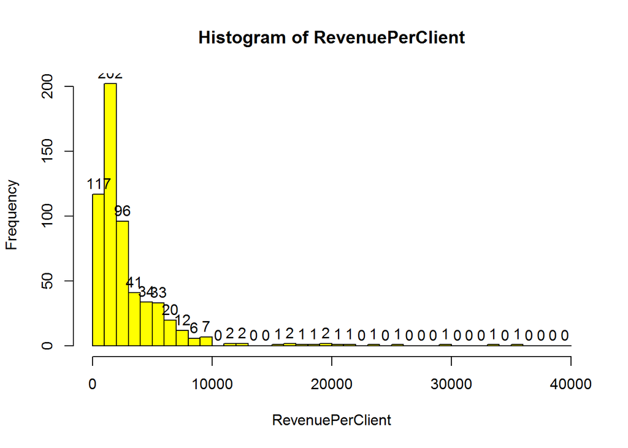

We then evaluated trends in hotel occupancy over time. As the hotel is located on the banks of a lake in Northeastern Poland (where it can get quite cold in the winter), it is no surprise to find that spring and summer are the most popular seasons for hotel visitors. From the table below, you can also see that fall and winter can be considered the hotel’s “off season.” This poses a strategic question for the owners of Masuria Arte - how can we better attract guests during our off season?

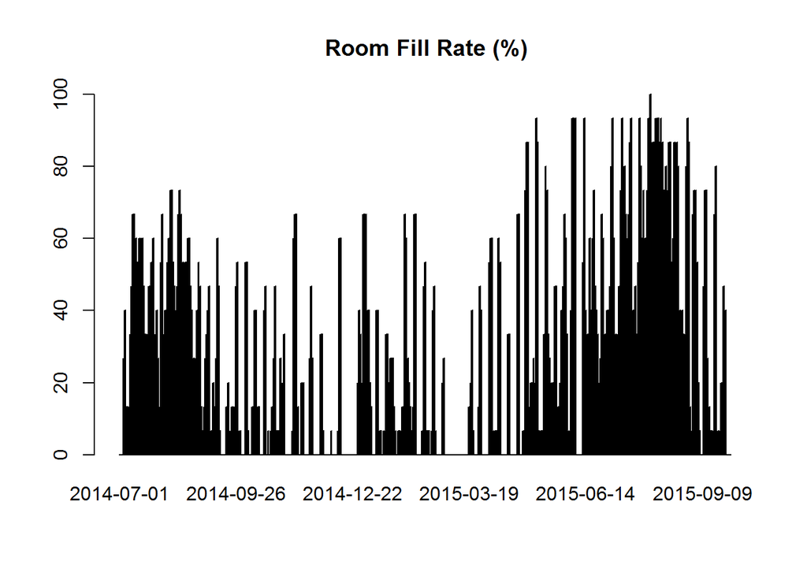

Consistent with occupancy rates, we also find that the majority of the hotel’s revenues are generated during the spring and summer months, which we have labeled as the peak season in the graph below.

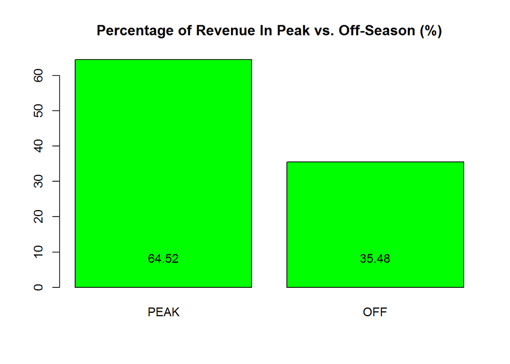

With lower occupancy rates in the off season, an opportunity exists to attract additional visitors during this period. We first sought to understand differences in the behaviors of peak season visitors and off season visitors. In the two graphs below we see that the off season visitor is much more likely to book their room in advance than the peak season traveler (20 days in advance versus 12 days in advance). We can infer that off season travelers are thinking through their travel plans further in advance, and to attract these customers Masuria Arte can increase occupancy rates by offering promotions towards the end of the peak season and at the beginning of the off season to encourage visitors who are already looking ahead and planning out their fall and winter vacations.

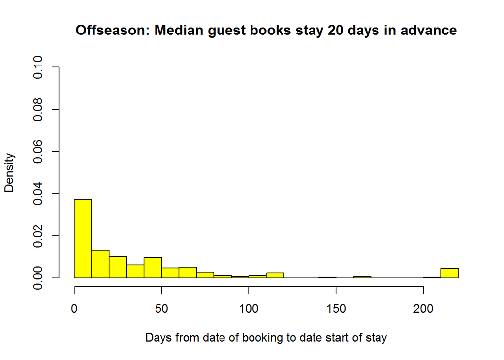

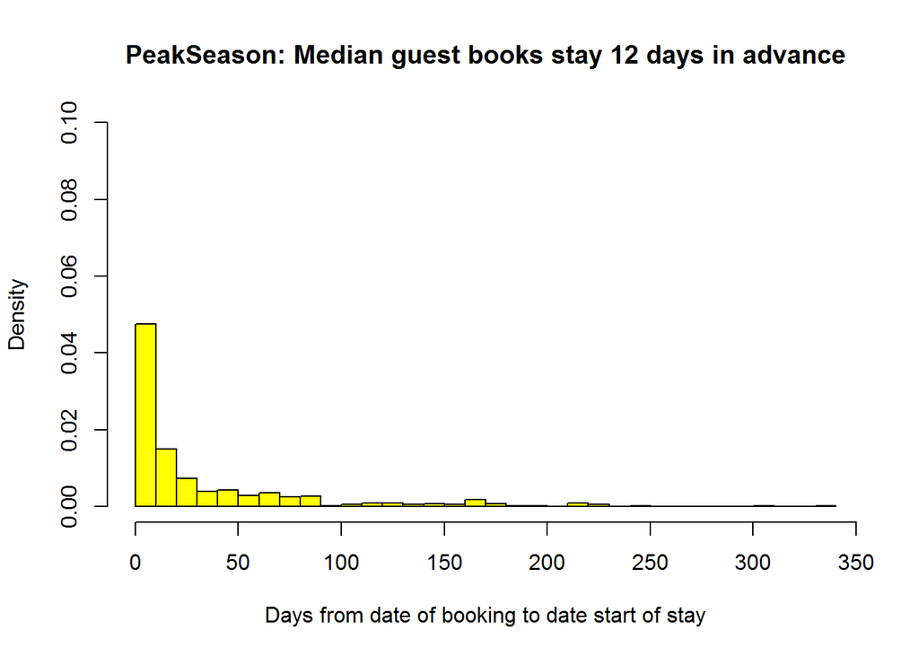

From the below two graphs we also see that off season visitors tend to book shorter visits at the hotel than their peak season counter parts.

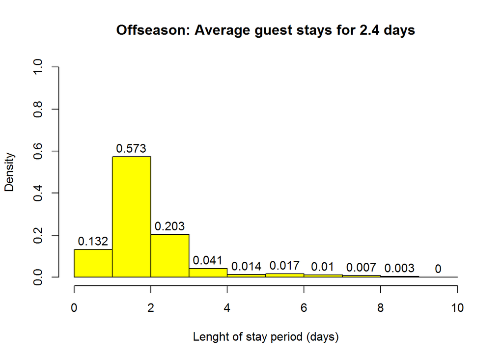

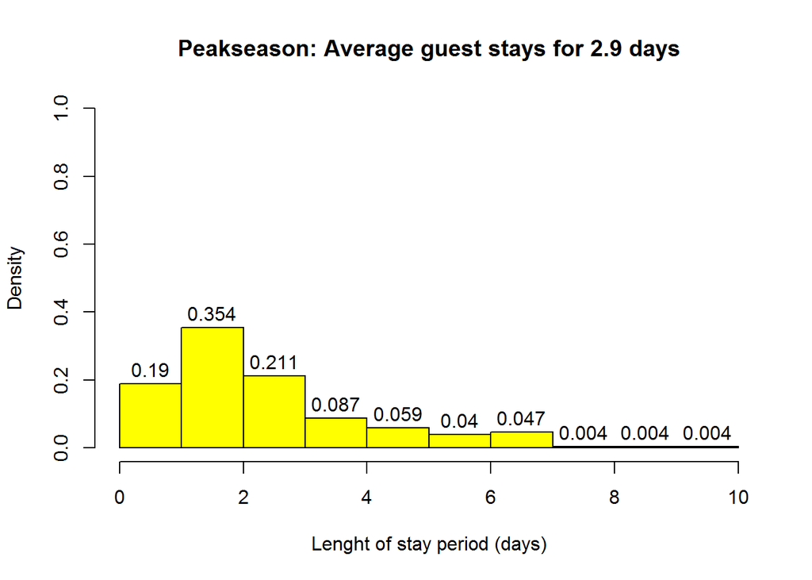

To understand the cause of the discrepancy between average stay duration, we tested the hypothesis that off season visitors were more likely to schedule their hotel stay over a weekend, whereas spring and summer guests were more likely to visit on a weekday, perhaps with children and family. The below table confirms this hypothesis. As can be noted, off season visitors are much less likely to schedule a visit during a week day than peak season visitors.

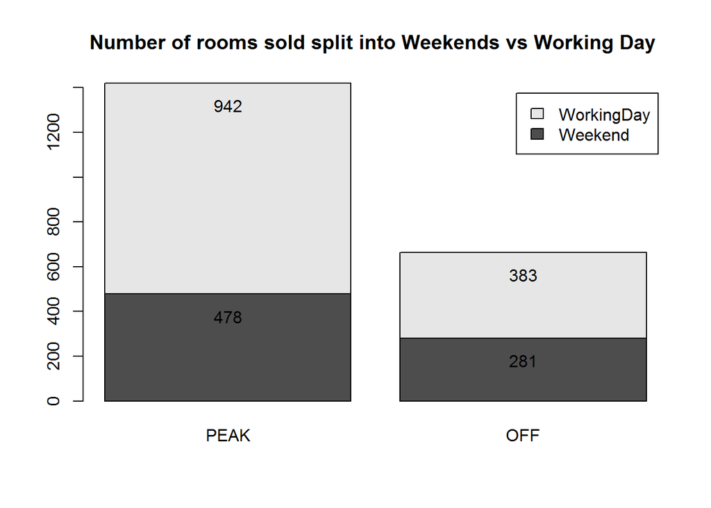

One thing to note while interpreting the graph above: an even spread of visits should have the ratio of 5 workdays visits to 2 weekend visits. Consequently, even though the off season shows a larger amount of weekday bookings than weekend bookings, given that there are more weekdays than weekend days, these visitors skew disproportionately towards weekend visits.

This presents two opportunities for Masuria Arte to improve off season occupancy rates. One is to advertise the hotel as the ideal weekend getaway to better target the segment of customers who tend to frequent the hotel more often during these off season. These advertisements could focus on some of the winter-friendly, indoor activities and amenities that the hotel offers (spa treatments, massages, gourmet, warm meals, relaxing by the fireplace away from the busy city, etc.)

Another strategy is to tap into a market segment that could bolster the weekday visits in the off season which are currently under-occupied. One such customer segment could include businesses who may be interested in using the site as an office retreat during the work week, or for similar business functions.